# gamm_derivatives

For a paper which collected light and photosynthesis data in a forest during the spring we needed to determine when we should considered the leaf emergence of the trees finished and the canopy “closed.”

The plot below shows how average daily light levels changed over time, with a GAM smooth fit to the data.

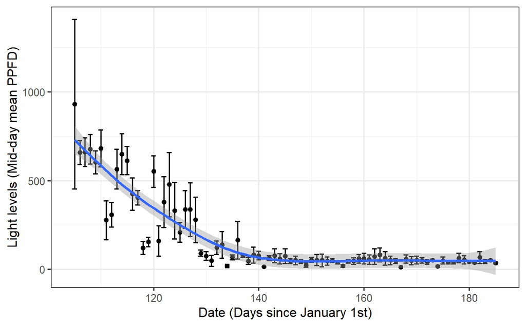

To determine when light levels were no longer changing, I adapted GAM derivative techniques discussed by Gavin Simpson on his [blog](https://fromthebottomoftheheap.net/). Often this is done arbitrarily, but we wanted to provided a justifiable and quantitative cutoff.

The figure below shows how the *derivative* for the smoother in the previous plot changes over time.

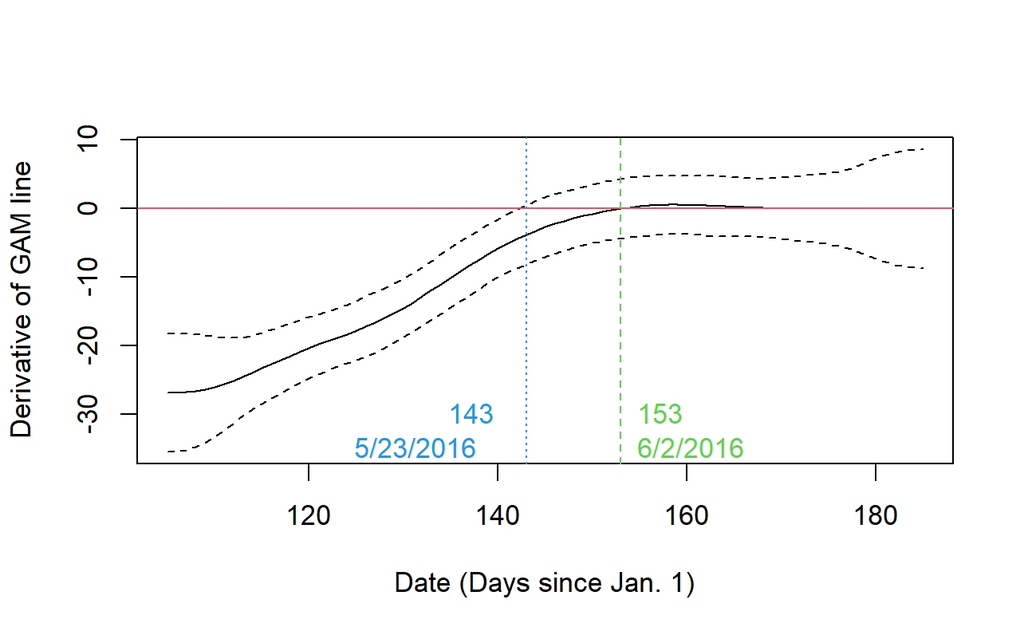